# Project 1: Wrangling, Exploration, Visualization

SDS322E

## Data Wrangling, Exploration, Visualization

### Noor Shenaq, ns32468

#### Introduction

The data sets come from the US Census Bureau and Kaggle data bases. There are 4 data sets “jee16t08”, “X2020_November_General_Election_Turnout_Rates”, “State_Populations”, and “us_regions”. The data sets were easily obtained from the sites GitHub Repository. These data sets are in particular interest to me since I was part of Student Government. Voter turnout is particulary something of interest to me because I believe citizens have an obligation to be part of the elections and cast their votes. It is interesting to me to see comparisons amongst different states and geographical regions as well as the population numbers.

The library that will be used for the majority of the project was downloaded. Then, the data sets that are going to be used were loaded.

```r
library(tidyverse)
library(readr)
library(dplyr)
library(gt)

jeee16t08 <- read_csv("jeee16t08.csv")
#View(jeee16t08)


X2020_November_General_Election_Turnout_Rates <- read_csv("2020 November General Election - Turnout Rates.csv")

#View(X2020_November_General_Election_Turnout_Rates)


State_Populations <- read_csv("State Populations.csv")
#View(State_Populations)


us_regions <- read.csv("us census bureau regions and divisions.csv")
#View(us_regions)
```

Before anything is done to the data, the data sets were viewed.

```r
jeee16t08 %>% glimpse()
```

```
## Rows: 52
## Columns: 11
## $ State                                     <chr> "Total", "Alabama", "Alaska"…
## $ `Population 2016`                         <dbl> 323071342, 4864745, 741504, …
## $ `Total justice system PC`                 <dbl> 722.70, 480.11, 1297.65, 709…
## $ `Police Protection PC`                    <dbl> 338.04, 257.21, 499.27, 325.…
## $ `Judicial and legal PC`                   <dbl> 143.18, 74.43, 342.55, 141.5…
## $ `Corrections PC`                          <dbl> 241.48, 148.47, 455.84, 242.…
## $ `Total justice system Employment`         <dbl> 63.12, 55.43, 77.18, 66.07, …
## $ `police protection Total Employment`      <dbl> 28.51, 29.08, 25.68, 28.30, …
## $ `police protection Sworn only Employment` <dbl> 21.73, 23.00, 15.58, 20.43, …
## $ `Judicial and legal Employment`           <dbl> 12.83, 9.73, 20.08, 15.91, 1…
## $ `Corrections Employment`                  <dbl> 21.78, 16.62, 31.42, 21.85, …
```

```r
X2020_November_General_Election_Turnout_Rates %>% glimpse()
```

```
## Rows: 52
## Columns: 15
## $ State                                 <chr> "United States", "Alabama", "Ala…
## $ Source                                <chr> NA, "https://www2.alabamavotes.g…
## $ `Official/Unofficial`                 <chr> NA, "Unofficial", NA, NA, "Unoff…
## $ `Total Ballots Counted (Estimate)`    <dbl> 158835004, 2306587, 367000, 3400…
## $ `Vote for Highest Office (President)` <dbl> NA, 2297295, NA, NA, 1206697, NA…
## $ `VEP Turnout Rate`                    <chr> "66.4%", "62.6%", "69.8%", "65.5…
## $ `Voting-Eligible Population (VEP)`    <dbl> 239247182, 3683055, 525568, 5189…
## $ `Voting-Age Population (VAP)`         <dbl> 257605088, 3837540, 551117, 5798…
## $ `% Non-citizen`                       <chr> "7.8%", "2.3%", "3.4%", "8.9%", …
## $ Prison                                <dbl> 1461074, 25898, 4293, 38520, 175…
## $ Probation                             <dbl> 1962811, 50997, 2074, 76844, 367…
## $ Parole                                <dbl> 616440, 10266, 1348, 7536, 24698…
## $ `Total Ineligible Felon`              <dbl> 3294457, 67782, 6927, 93699, 649…
## $ `Overseas Eligible`                   <dbl> 4971025, NA, NA, NA, NA, NA, NA,…
## $ `State Abv`                           <chr> NA, "AL", "AK", "AZ", "AR", "CA"…
```

```r
State_Populations %>% glimpse()
```

```
## Rows: 51
## Columns: 2
## $ State             <chr> "California", "Texas", "Florida", "New York", "Penns…
## $ `2018 Population` <dbl> 39776830, 28704330, 21312211, 19862512, 12823989, 12…
```

```r
us_regions %>% glimpse()
```

```
## Rows: 51
## Columns: 4
## $ State      <chr> "Alaska", "Alabama", "Arkansas", "Arizona", "California", "…
## $ State.Code <chr> "AK", "AL", "AR", "AZ", "CA", "CO", "CT", "DC", "DE", "FL",…
## $ Region     <chr> "West", "South", "South", "West", "West", "West", "Northeas…
## $ Division   <chr> "Pacific", "East South Central", "West South Central", "Mou…
```

#### Tidying: Reshaping

If your datasets are tidy already, demonstrate that you can reshape data with pivot wider/longer here (e.g., untidy and then retidy). Alternatively, it may be easier to wait until the wrangling section so you can reshape your summary statistics. Note here if you are going to do this.

All data was tidied up. The unessesary columns were removed from the data sets and the columns that we will be using remain.

```r
# your tidying code (if applicable; can also wait until wrangling section)

jeee16t08 %>% view()
cleaned1 <- jeee16t08 %>% select(1,10)
cleaned1 %>% view()



X2020_November_General_Election_Turnout_Rates %>% view()
cleaned2 <- X2020_November_General_Election_Turnout_Rates %>% select(1,6)
cleaned2 %>% view()


us_regions %>% view()
cleaned3 <- us_regions %>% select(1,4)
cleaned3 %>% view()
```

#### Joining/Merging

Here I joined the four data sets.

```r
combined <- left_join( State_Populations, cleaned1, by = c("State")) %>%
  left_join(cleaned2, by = c("State")) %>% left_join(cleaned3, by = c("State"))


combined %>% glimpse(51)
```

```
## Rows: 51
## Columns: 5
## $ State                           <chr> "Californ…
## $ `2018 Population`               <dbl> 39776830,…
## $ `Judicial and legal Employment` <dbl> 11.31, 10…
## $ `VEP Turnout Rate`              <chr> "64.7%", …
## $ Division                        <chr> "Pacific"…
```

#### Wrangling

```r
dirty <- combined %>% pivot_wider(names_from = Division, values_from = Division)
dirty %>% glimpse(100)
```

```
## Rows: 51
## Columns: 13
## $ State                           <chr> "California", "Texas", "Florida", "New York", "Pennsylvani…
## $ `2018 Population`               <dbl> 39776830, 28704330, 21312211, 19862512, 12823989, 12768320…
## $ `Judicial and legal Employment` <dbl> 11.31, 10.00, 15.12, 15.90, 14.17, 10.68, 17.03, 13.89, 7.…
## $ `VEP Turnout Rate`              <chr> "64.7%", "60.2%", "71.7%", "65.3%", "70.5%", "67.6%", "68.…
## $ Pacific                         <chr> "Pacific", NA, NA, NA, NA, NA, NA, NA, NA, NA, NA, NA, "Pa…
## $ `West South Central`            <chr> NA, "West South Central", NA, NA, NA, NA, NA, NA, NA, NA, …
## $ `South Atlantic`                <chr> NA, NA, "South Atlantic", NA, NA, NA, NA, "South Atlantic"…
## $ `Middle Atlantic`               <chr> NA, NA, NA, "Middle Atlantic", "Middle Atlantic", NA, NA, …
## $ `East North Central`            <chr> NA, NA, NA, NA, NA, "East North Central", "East North Cent…
## $ Mountain                        <chr> NA, NA, NA, NA, NA, NA, NA, NA, NA, NA, NA, NA, NA, "Mount…
## $ `New England`                   <chr> NA, NA, NA, NA, NA, NA, NA, NA, NA, NA, NA, NA, NA, NA, "N…
## $ `East South Central`            <chr> NA, NA, NA, NA, NA, NA, NA, NA, NA, NA, NA, NA, NA, NA, NA…
## $ `West North Central`            <chr> NA, NA, NA, NA, NA, NA, NA, NA, NA, NA, NA, NA, NA, NA, NA…
```

```r
#combined %>% str()

combined %>%
  mutate(Division = as.character(Division))
```

```
## # A tibble: 51 × 5
##    State          `2018 Population` `Judicial and leg… `VEP Turnout Ra… Division
##    <chr>                      <dbl>              <dbl> <chr>            <chr>
##  1 California              39776830              11.3  64.7%            Pacific
##  2 Texas                   28704330              10    60.2%            West So…
##  3 Florida                 21312211              15.1  71.7%            South A…
##  4 New York                19862512              15.9  65.3%            Middle …
##  5 Pennsylvania            12823989              14.2  70.5%            Middle …
##  6 Illinois                12768320              10.7  67.6%            East No…
##  7 Ohio                    11694664              17.0  68.9%            East No…
##  8 Georgia                 10545138              13.9  68.1%            South A…
##  9 North Carolina          10390149               7.43 72.2%            South A…
## 10 Michigan                 9991177              10.8  73.6%            East No…
## # … with 41 more rows
```

Then, stringer and mutate function was used to remove the percentage sign from the end of each index in the VEP Turnout Rate. Then, the arrange function organized the VEP turn out rate from least to greatest.

```r
combinednew <- combined %>% mutate(`VEP Turnout Rate`= str_replace_all(`VEP Turnout Rate`, "%","")) %>% arrange(`VEP Turnout Rate`) %>% mutate(`VEP Turnout Rate`= as.numeric(`VEP Turnout Rate`)) %>% mutate(Division = as.character(Division))
```

Now, the select function was used to isolate voter turn out according to state.

```r
combined2 <- combined %>% mutate(`VEP Turnout Rate`= str_replace_all(`VEP Turnout Rate`, "%","")) %>% arrange(`VEP Turnout Rate`) %>% select(State, `VEP Turnout Rate`, Division )

view(combined2)
```

Looking at these columns together allows us to see clearly that Oklahoma had the lowest voter turnout being 55% and Minnesota had the highest VEP Turnout Rate being 79.9%.

Next, the filter function was applied to see how many of those voter turn outs were considered in the mountain region. Maybe looking at geography might affect the number of voters.

```r
combined2 %>% filter( Division == "Mountain" )
```

```
## # A tibble: 8 × 3
##   State      `VEP Turnout Rate` Division
##   <chr>      <chr>              <chr>
## 1 New Mexico 61.0               Mountain
## 2 Nevada     63.6               Mountain
## 3 Wyoming    64.6               Mountain
## 4 Arizona    65.5               Mountain
## 5 Utah       66.2               Mountain
## 6 Idaho      67.7               Mountain
## 7 Montana    73.1               Mountain
## 8 Colorado   76.4               Mountain
```

Seeing that the mountain region was filtered and the values are close to both the minimum and maximum, we cannot see much of a relationship between division and voter turnout.

Next, we run a summary statistic for the entire data set.

```r
combinednew %>% summarize_if(is.numeric, median) %>% glimpse(51)
```

```
## Rows: 1
## Columns: 3
## $ `2018 Population`               <dbl> 4472265
## $ `Judicial and legal Employment` <dbl> 12.74
## $ `VEP Turnout Rate`              <dbl> 67.6
```

Next, we grouped them by division and used the summarize function to compute the median, mean, standard deviation, minimum and maximum for each of the columns in the data set for the numerical variables.

```r
combinednew %>% group_by(Division) %>% summarize_if(is.numeric, funs(median,
    mean, sd, min, max)) %>% as.data.frame()
```

```
##             Division 2018 Population_median
## 1 East North Central                9991177
## 2 East South Central                4680607
## 3    Middle Atlantic               12823989
## 4           Mountain                2573766
## 5        New England                1346078
## 6            Pacific                4199563
##   Judicial and legal Employment_median VEP Turnout Rate_median
## 1                               10.770                   68.90
## 2                               10.525                   61.50
## 3                               15.900                   70.50
## 4                               15.320                   65.85
## 5                               11.660                   73.70
## 6                               11.540                   69.80
##   2018 Population_mean Judicial and legal Employment_mean VEP Turnout Rate_mean
```

[output cut: 28 more lines]

#### Visualizing

A bar graph was made to depict the voter turnout by state.

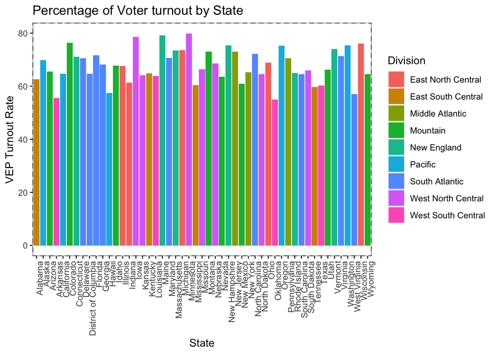

```r
combinednew %>% ggplot(aes(x = State, y= `VEP Turnout Rate`, fill = Division)) + geom_bar(stat = "summary", fun = mean) + geom_errorbar(stat = "summary", width = .5, color = "green") + theme(panel.border = element_rect(linetype = "dashed", fill = NA)) + scale_y_continuous(breaks = seq(50, 80, 2)) + labs (title = "Percentage of Voter turnout by State", x = "State", y = "VEP Turnout Rate") + theme(axis.text.x = element_text(angle = 90,
    hjust = 1), panel.background = element_rect(fill = "white",
    colour = "grey50")) + scale_y_continuous(breaks = seq(from = 0, to = 100, by = 20),
        name = "VEP Turnout Rate")
```

In this bar graph you can see how percentage of voters for each state. The different colors represent the different divisions. It does not seem as if there is some relationship between different startes and the voter turnouts. The highest voter turnout is Minnesota which is the West North Central.

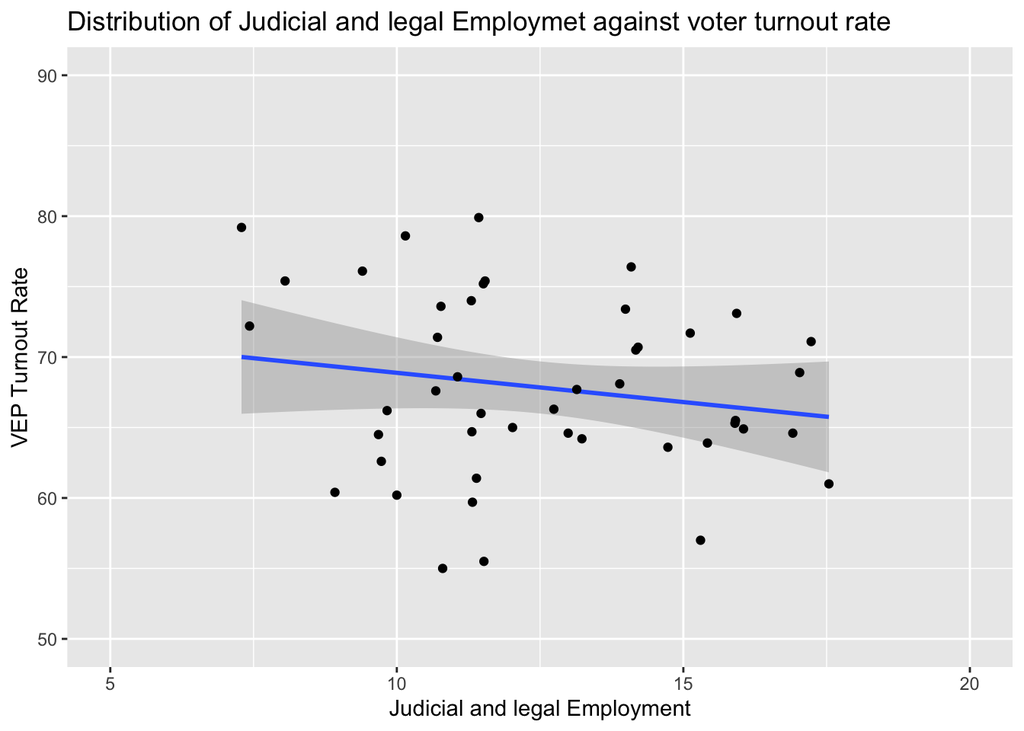

```r
combinednew %>% ggplot(aes(`Judicial and legal Employment`, `VEP Turnout Rate`)) + geom_smooth(method = "lm") + theme(legend.position = "top") + scale_x_continuous(lim = c(5, 20)) + scale_y_continuous(lim = c(50,90)) + labs(title = "Distribution of Judicial and legal Employmet against voter turnout rate", x = "Judicial and legal Employment", y = "VEP Turnout Rate") + geom_point()
```

In this plot, judicial and legal employment are on the x-axis, while VEP Turnout Rate is on the y-axis. It appears that the data points are concentrated in the middle of this graph. It does not seem like there is a correlation between judicial and legal employment and voter turnout however the line of best fit appears to be sloping slightly downwards suggesting higher turnouts are more associated with less legal employment. Maybe because this type of employment takes up time and calls for a busy schedule, it may decrease time to get to the polls.

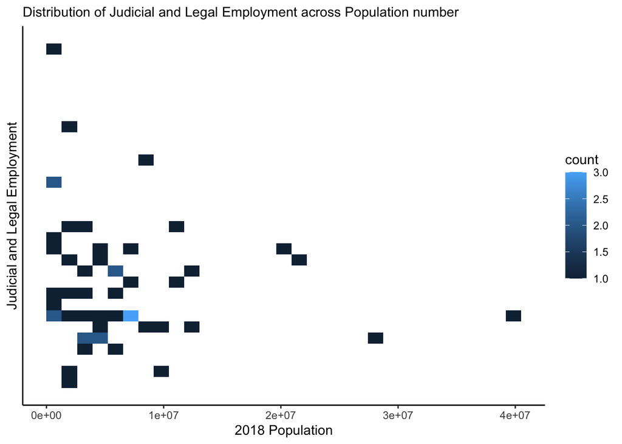

```r
combinednew %>% ggplot(aes(`2018 Population`, `Judicial and legal Employment`)) + geom_bin2d() + geom_hex() + theme_classic() + labs(title = "Distribution of Judicial and Legal Employment across Population number", x = "2018 Population", y = "Judicial and Legal Employment") + theme(plot.title = element_text(size = rel(1))) + scale_y_continuous(breaks = seq(10,30,1) + scale_fill_gradient(low = "Blue", high = "Black"))
```

This plot shows a distribution of judicial and legal employment across the population. It appears that the more smaller populations have more judicial and legal employmet in general.

#### Concluding Remarks

This data analysis project was merely to explore and utilize the important functions. While I wanted to see if there were correlations with voter turnout, population, division,and legal occupation there was not enough information to see any strong associations.